# Machine Learning: Assignment

SS

September 18, 2017

## Background

Using devices such as Jawbone Up, Nike FuelBand, and Fitbit it is now possible to collect a large amount of data about personal activity relatively inexpensively. These type of devices are part of the quantified self movement - a group of enthusiasts who take measurements about themselves regularly to improve their health, to find patterns in their behavior, or because they are tech geeks. One thing that people regularly do is quantify how much of a particular activity they do, but they rarely quantify how well they do it. In this project, your goal will be to use data from accelerometers on the belt, forearm, arm, and dumbell of 6 participants. They were asked to perform barbell lifts correctly and incorrectly in 5 different ways. More information is available from the website here: http://groupware.les.inf.puc-rio.br/har (see the section on the Weight Lifting Exercise Dataset).

## Data used

The training data for this project are available here: https://d396qusza40orc.cloudfront.net/predmachlearn/pml-training.csv The test data are available here: https://d396qusza40orc.cloudfront.net/predmachlearn/pml-testing.csv

The data for this project come from this source: http://groupware.les.inf.puc-rio.br/har. If you use the document you create for this class for any purpose please cite them as they have been very generous in allowing their data to be used for this kind of assignment.

## Desired Output

The goal of your project is to predict the manner in which they did the exercise. This is the “classe” variable in the training set. You may use any of the other variables to predict with. You should create a report describing how you built your model, how you used cross validation, what you think the expected out of sample error is, and why you made the choices you did. You will also use your prediction model to predict 20 different test cases.

## Cleaning Data

We will remove NA variables

```r
trainCl<-trainSet[, apply(trainSet, 2, function(x) !any(is.na(x)))]
dim(trainCl)
```

```
## [1] 19622    60
```

Remove columns of low importance

```r
trainClean<-trainCl[,-c(1:8)]
dim(trainClean)
```

```
## [1] 19622    52
```

Creating 20 test cases

```r
testingClean<-testSet[,names(trainClean[,-52])]
dim(testingClean)
```

```
## [1] 20 51
```

## Partition Data

The cleaned up set is to be divided into training and testing

```r
trainSetX <- createDataPartition(y=trainClean$classe, p=0.7, list=FALSE)
training <- trainClean[trainSetX,];
testing <- trainClean[-trainSetX,]

dim(training);
```

```
## [1] 13737    52
```

```r
dim(testing)
```

```
## [1] 5885   52
```

There are 13737 samples over 52 variables for training and 5885 over 52 variables for testing.

## Analysis

Starting with a Random Forest Model

```r
modelRandomForest <- randomForest(as.factor(classe) ~ ., data = training)
predictRandomForest <- predict(modelRandomForest, testing, type = "class")
confusionMatrix(predictRandomForest, testing$classe)
```

```
## Confusion Matrix and Statistics
##
##           Reference
## Prediction    A    B    C    D    E
##          A 1673    4    0    0    0
##          B    1 1134    4    0    0
##          C    0    1 1021   10    0
##          D    0    0    1  953    2
##          E    0    0    0    1 1080
##
## Overall Statistics
##
##                Accuracy : 0.9959
##                  95% CI : (0.9939, 0.9974)
##     No Information Rate : 0.2845
##     P-Value [Acc > NIR] : < 2.2e-16
##
##                   Kappa : 0.9948
##  Mcnemar's Test P-Value : NA
##
## Statistics by Class:
##
##                      Class: A Class: B Class: C Class: D Class: E
## Sensitivity            0.9994   0.9956   0.9951   0.9886   0.9982
## Specificity            0.9991   0.9989   0.9977   0.9994   0.9998
## Pos Pred Value         0.9976   0.9956   0.9893   0.9969   0.9991
## Neg Pred Value         0.9998   0.9989   0.9990   0.9978   0.9996
## Prevalence             0.2845   0.1935   0.1743   0.1638   0.1839
## Detection Rate         0.2843   0.1927   0.1735   0.1619   0.1835
## Detection Prevalence   0.2850   0.1935   0.1754   0.1624   0.1837
## Balanced Accuracy      0.9992   0.9973   0.9964   0.9940   0.9990
```

The confusion matrix was created to test the accuracy of the model which appears to be above 99% based on the above.

A second model - Decision Tree - will be applied to see whether it is more accurate

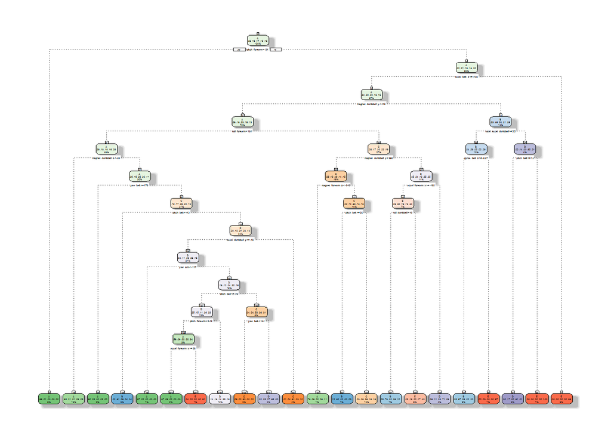

```r
modelDecisionTree <- rpart(as.factor(classe) ~ ., data = training, method = "class")
fancyRpartPlot(modelDecisionTree,sub = "")
```

```r
predictDecisionTree <- predict(modelDecisionTree, testing, type = "class")

confusionMatrix(predictDecisionTree, testing$classe)
```

```
## Confusion Matrix and Statistics
##
##           Reference
## Prediction    A    B    C    D    E
##          A 1476  198    8   76   61
##          B   38  577   53   23  115
##          C   30   90  765  151  180
##          D  105  207  135  663  130
##          E   25   67   65   51  596
##
## Overall Statistics
##
##                Accuracy : 0.6928
##                  95% CI : (0.6808, 0.7046)
##     No Information Rate : 0.2845
##     P-Value [Acc > NIR] : < 2.2e-16
##
##                   Kappa : 0.6111
##  Mcnemar's Test P-Value : < 2.2e-16
##
## Statistics by Class:
##
##                      Class: A Class: B Class: C Class: D Class: E
## Sensitivity            0.8817  0.50658   0.7456   0.6878   0.5508
## Specificity            0.9185  0.95175   0.9072   0.8827   0.9567
## Pos Pred Value         0.8114  0.71588   0.6291   0.5347   0.7413
## Neg Pred Value         0.9513  0.88935   0.9441   0.9352   0.9043
## Prevalence             0.2845  0.19354   0.1743   0.1638   0.1839
## Detection Rate         0.2508  0.09805   0.1300   0.1127   0.1013
## Detection Prevalence   0.3091  0.13696   0.2066   0.2107   0.1366
## Balanced Accuracy      0.9001  0.72917   0.8264   0.7853   0.7538
```

## Conclusion

The Decision Tree model results in a much lower accuracy (under 90%) so Random Forests is a better choice

Applying Random Forest model on the set

```r
predict(modelRandomForest, newdata = testingClean)
```

```
##  1  2  3  4  5  6  7  8  9 10 11 12 13 14 15 16 17 18 19 20
##  B  A  B  A  A  E  D  B  A  A  B  C  B  A  E  E  A  B  B  B
## Levels: A B C D E
```